# Project - Predicting Mortality in ICU Patients

Lucie Gillet, Maja Garbulinska, Anthony O’Brien, Mathew Samuel

12/12/2018

# Overview and Motivation:

Provide an overview of the project goals and the motivation for it. Consider that this will be read by people who did not see your project proposal

With the increasing proliferation of data, there continues to be a shift towards data-driven decision making, especially in the world of healthcare. The ICU represents a particularly interesting opportunity given the numerous data elements collected on patients to monitor their health at this critical juncture. Currently, there are a variety of risk prediction scores that clinicians are able to utilize to gain some insight into the overall health of their patient in the aggregate.

For our project, we wanted to see if we could take advantage of the many data points collected and develop a mortality prediction model based on a patient’s first day in the ICU, which remains a particularly important period in their hospital admission. Such a model would provide physicians with a data-driven, standardized approach to assess the overall health of their patient and also potentially inform clinical decision-making moving forward. For instance, though it may be heuristically clear at times which patients might need increased supervision, a robust and standardized score would provide for a systematic, process-driven method to help hospitals allocate resources on patients that require the most attention.

# Related Work:

Anything that inspired you, such as a paper, a web site, or something we discussed in class

We were inspired by a paper written by our MIT course faculty on [Real-time mortality prediction in the Intensive Care Unit](https://www.ncbi.nlm.nih.gov/pmc/articles/PMC5977709/). We wanted to tackle a relevant and feasible problem given the scope of the class, so decided to modify the task to develop a mortality prediction based on first day measurements.

# Initial Questions:

What questions are you trying to answer? How did these questions evolve over the course of the project? What new questions did you consider in the course of your analysis?

The main question we are trying to answer is as follows: can we accurately predict a patient’s in-hospital mortality based on their first-day readings in the ICU? Over the course of our project, we also wondered if we could understand the impact of the first 24 hours in the ICU on longer-term patient mortality, though it’s clear that as more time passes from the initial ICU stay to the time of death, there could be additional factors to take into account, a number of which do not have corresponding data. After working with the data, we also faced the challenge of dealing with patients who were admitted to the ICU at multiple time points, sometimes within the same hospital admission.

As we continued our analysis, we also wondered whether we should incorporate current scores that we aim to compare against in our model. In the end, we decided that these were acceptable to incorporate considering that these readings are automatically calculated for patients in the ICU and more importantly, these scores provided an effective proxy in helping us understand the nuance of clinical values in the absence of additional clinical expertise. If this model were to be implemented in the future, it would be important to incorporate some of the scores and buckets created in different scoring methods to accurately convey information on how ‘good’ or ‘bad’ certain values are.

In the course of our analysis, one of the greatest challenges we faced was thinking about how we would deal with missing data. While we did initially consider looking at various imputation methods, we decided to develop a parsimonious model with reasonable accuracy given the variety of challenges of imputation in a clinical setting after consulting various clinicians and given the time frame of the project.

# Data:

Source, scraping method, cleanup, etc

For our Collaborative Data Science in Medicine class, the MIMIC database was hosted in Google Bigquery. We developed sql queries and then combined the dataframe into a temporary folder provisioned in bigquery, from which we imported the data into R with a connection. As we cannot provide account access and for the sake of reproducibility, we placed an extract of the query result in an Rda file to analyze going forward.

# Exploratory Analysis:

### What visualizations did you use to look at your data in different ways? What are the different statistical methods you considered? Justify the decisions you made, and show any major changes to your ideas. How did you reach these conclusions?

We first used a variety of exploratory plots, including histograms and barplots to understand the distribution of our data to identify outliers, missing data and the shape of distributions to potentially inform further methods. At its core, our research question is a classification problem, so we decided to use logistic regression along with tree based methods, including first a simple decision tree, then a random forest and a gradient boosted tree.

# Final Analysis: What did you learn about the data? How did you answer the questions? How can you justify your answers?

We learned that we are able to develop a reasonable estimate with just first day readings in the ICU, but need to incorporate additional complexity in order to effectively implement this algorithm in a clinical setting. In our context, sensitivity refers to our ability to accuratelly predict patients who survived past their stay in the hospital among the total patients alive. Specificity refers to our ability to predict deaths among patients that died. Different scores are currently used in hospitals to predict mortality, for example SOFA, OASIS and SAPS II and we were able to outperform all of them. As mentioned at the beginning of the project, we sought to develop a decision support tool, and believe that our algorithm could be used to help clinicians better understand a patient’s future prognosis.

```r
##This is the script with credentials to grab the data from bigquery, we fetched the data 1000 rows at a time due to the challenges with the API (there is an issue log open with the developers it seems to try and resolve it, but this is a fix for now)
#library("bigrquery")
# Load configuration settings
# project_id <- "hst-953-2018"
# options(httr_oauth_cache=TRUE)
#
# run_query <- function(query){
#   data <- query_exec(query, project=project_id, use_legacy_sql = FALSE)
#   return(data)
# }
#
# hds<-NULL
# system.time(
#   for(i in 1:65) {
#     query_sql <- paste('SELECT * FROM `hst-953-2018.temp_n.hds_1213` LIMIT ',1000,' OFFSET ',1000*(i-1),sep='')
#     hdsi <- run_query(query_sql)
#     hds<-rbind(hds,hdsi)
#     paste(1000*i,'records of data grabbed')
#   })
#
# save(hds,file="hds_1213.Rda")

load('../data/hds_1213.Rda')
hds<-hds %>% unique() # make sure we dont have duplicates
```

We find that some people died before admission to the ICU. This is a mistake so we delete them from the dataset

```r
hds<- hds %>%
  mutate(deathdiff=difftime(deathtime,intime, unit="days"))%>%
  mutate(diedEver=ifelse(!is.na(deathtime), 1, 0))%>%
  mutate(died24H=ifelse(!is.na(deathtime) & as.numeric(deathdiff)<=1, 1, 0))%>%
  filter(deathdiff>=0  | is.na(deathdiff))%>%
  select(-diedEver)
## delete negative values - people who died before they were admitted - this is a mistake
```

Let’s look at the plot of when people die.

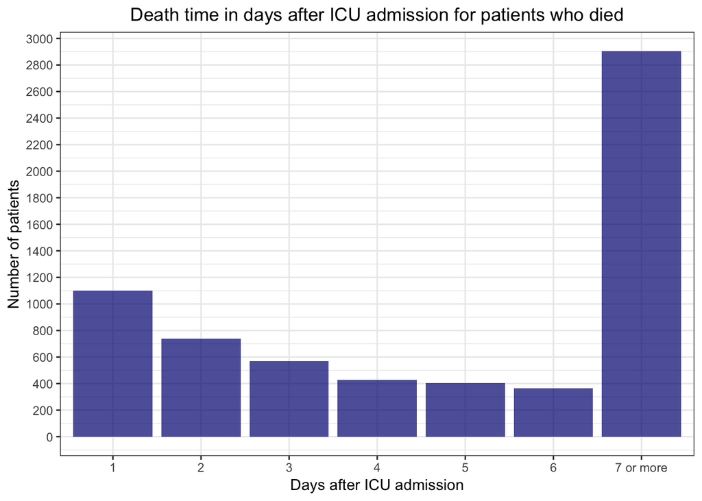

```r
plot<-hds %>%
  mutate(deathdiff=ceiling(deathdiff))%>%
  mutate(deathDAYS=ifelse(deathdiff<7, deathdiff, "7 or more"))%>%
  filter(!is.na(deathDAYS))%>%
  ggplot(data=.)+
  geom_histogram(aes(x=deathDAYS), stat = "count", fill="navyblue", alpha=0.7)+
  xlab("Days after ICU admission")+
  ylab("Number of patients")+
  ggtitle("Death time in days after ICU admission for patients who died")+
  theme_bw()+
  theme(plot.title = element_text(hjust = 0.5))+
  scale_y_continuous(breaks=seq(0, 3000, 200))
plot
```

We create a flag for people who die within the first 24h in the ICU. We exclude them from our analysis

```r
hds <- hds %>% filter(died24H!=1)
```

## Plot to obtain the missing values:

```r
# missmap(hds)
```

Time since last ICU admission (taking 1/number of days since the last icu stay. People who are in the ICU for the first time will get 0) We also remove patients with missing values for intime and outtime, because their ICU stay might just be an entry error.

```r
subset_hds<- hds %>% select(subject_id, hadm_id, icustay_id, intime, outtime) %>%
  arrange(subject_id, intime) %>%  ## make sure that data are arrange correctly
  group_by(subject_id) %>%
  mutate(lag=lag(intime, 1),
         difftime=difftime(intime, lag, units="days"),
         difftime=1/as.numeric(difftime),
         difftime=ifelse(is.na(difftime),0,difftime), ## if you have never been to the ICU you get 0
         isnaintime=ifelse(is.na(intime), 1, 0), ## eliminate people if they have missing intime at least once
         max=max(isnaintime))%>%
  filter(max!=1) %>%
  select(subject_id, icustay_id, difftime) %>%
  ungroup()


hds2<-left_join(hds, subset_hds) ## merge/join with the whole dataset
rm(subset_hds) ## remove this dataframe, we dont need it anymore
```

## Remove people with missing gender.

```r
hds2<-hds2 %>% filter(!is.na(gender))
```

## Remove all the columns with more than 20% of missing values

```r
threshold <- nrow(hds)*0.20
hds <- hds2[colSums(is.na(hds2)) < threshold]
```

## Remove patients who have missing values for the rest of the columns

```r
hds <- hds[rowSums(is.na(hds)) < 1,]
```

First, we exclude all the patients who do not meet our inclusion criteria. Due to physiological differences, we exclude everyone who is under 18 years old and bin age. We also dummify gender.

```r
hds <- hds %>% filter(age>=18) %>%
  mutate(age = ifelse(age>89, 92, age),
         gender=ifelse(gender=="F", 1,0),
         age=cut(admission_age,
                 breaks=c(17, 28, 38, 48, 58, 68, 78, 88, Inf),
                 labels=c("1","2","3","4","5","6","7", "8")))%>%
  mutate(age=as.numeric(age))%>%
  select(-admission_age)
```

We can see the age distribution now

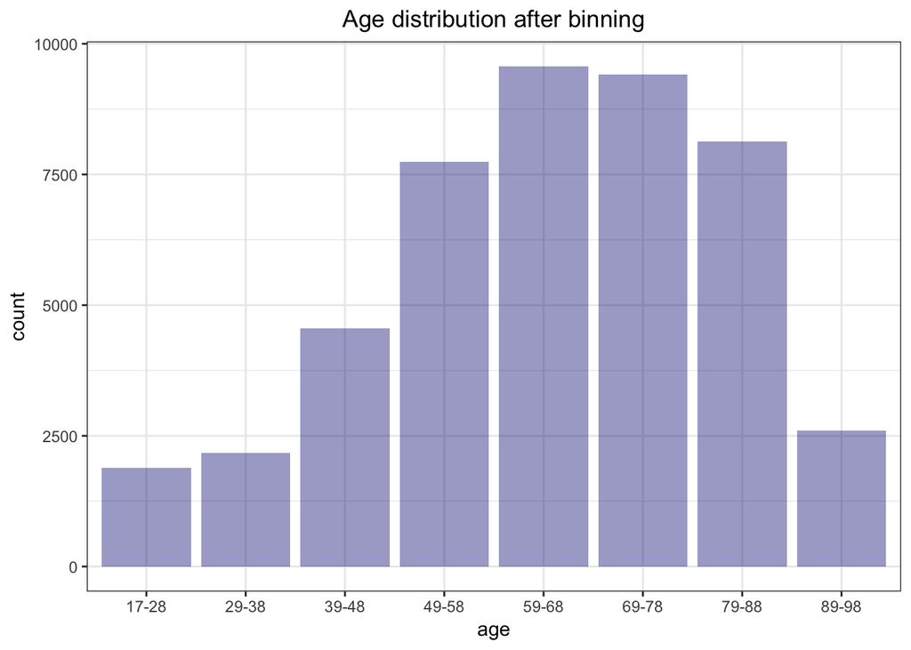

```r
hds %>%mutate(age=case_when(age==1~"17-28",
                               age==2~"29-38",
                               age==3~"39-48",
                               age==4~"49-58",
                               age==5~"59-68",
                               age==6~"69-78",
                               age==7~"79-88",
                               age==8~"89-98")) %>%
  ggplot(aes(x=age), data=.)+
  geom_histogram( fill="navyblue", stat="count", alpha=0.4)+
  theme_bw()+
  ggtitle("Age distribution after binning")+
  theme(plot.title = element_text(hjust = 0.5))
```

Gender distribution - 44 % are females

```r
summary(hds$gender)
```

```
##    Min. 1st Qu.  Median    Mean 3rd Qu.    Max.
##  0.0000  0.0000  0.0000  0.4375  1.0000  1.0000
```

```r
summary(hds$icustay_expire_flag) ## this is our outcome variable
```

```
##    Min. 1st Qu.  Median    Mean 3rd Qu.    Max.
## 0.00000 0.00000 0.00000 0.06528 0.00000 1.00000
```

We can see that some of the urine output entry are negative. After consulting this issue with domain experts, we recode these values to positive.

```r
summary(hds$urineoutput)
```

```
##    Min. 1st Qu.  Median    Mean 3rd Qu.    Max.
##   -1820    1035    1685    1953    2560  561190
```

## Urine output distribution

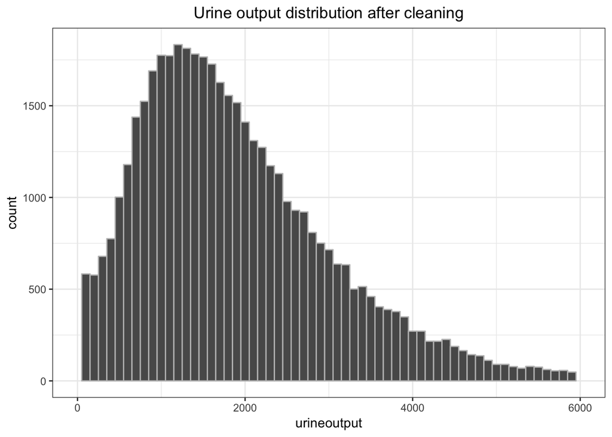

```r
ggplot(aes(x=urineoutput), data=hds)+
  geom_histogram( colour="grey",binwidth = 100)+
  theme_bw()+
  ggtitle("Urine output distribution after cleaning")+
  theme(plot.title = element_text(hjust = 0.5))+
  scale_x_continuous(limits=c(0,6000)) ## there are some crazy values later
```

```r
hds<-hds %>% mutate(urineoutput=abs(urineoutput))%>%
  filter(urineoutput<6001) ## urine output cant be more than this. We dont know if more is actually mistake
## since we have many patients we can eliminate these people
```

## Reclassifying the ethnicity variable

```r
hds$ethnicity <- str_replace_all(hds$ethnicity, 'HISPANIC/LATINO - CENTRAL AMERICAN (OTHER)', 'HISPANIC OR LATINO')
hds$ethnicity <- str_replace_all(hds$ethnicity, 'NATIVE/ALASKA NATIVE', 'NATIVE')
hds$ethnicity <- str_replace_all(hds$ethnicity, 'AMERICAN INDIAN', 'NATIVE')
hds$ethnicity <- str_replace_all(hds$ethnicity, 'AMERICAN INDIAN/ALASKA', 'NATIVE')
hds$ethnicity <- str_replace_all(hds$ethnicity, 'NATIVE/ALASKA NATIVE', 'NATIVE')
hds$ethnicity <- str_replace_all(hds$ethnicity, 'NATIVE/ALASKA NATIVE FEDERALLY RECOGNIZED TRIBE', 'NATIVE')
hds$ethnicity <- str_replace_all(hds$ethnicity, 'ASIAN - ASIAN INDIAN', 'ASIAN')
hds$ethnicity <- str_replace_all(hds$ethnicity, 'ASIAN - CHINESE', 'ASIAN')
hds$ethnicity <- str_replace_all(hds$ethnicity, 'ASIAN - CAMBODIAN', 'ASIAN')
hds$ethnicity <- str_replace_all(hds$ethnicity, 'ASIAN - FILIPINO', 'ASIAN')
hds$ethnicity <- str_replace_all(hds$ethnicity, 'ASIAN - JAPANESE', 'ASIAN')
hds$ethnicity <- str_replace_all(hds$ethnicity, 'ASIAN - KOREAN', 'ASIAN')
hds$ethnicity <- str_replace_all(hds$ethnicity, 'ASIAN - OTHER|ASIAN - THAI', 'ASIAN')
hds$ethnicity <- str_replace_all(hds$ethnicity, 'ASIAN - VIETNAMESE', 'ASIAN')
hds$ethnicity <- str_replace_all(hds$ethnicity, 'BLACK/AFRICAN', 'BLACK')
hds$ethnicity <- str_replace_all(hds$ethnicity, 'BLACK/AFRICAN AMERICAN', 'BLACK')
hds$ethnicity <- str_replace_all(hds$ethnicity, 'BLACK/CAPE VERDEAN', 'BLACK')
hds$ethnicity <- str_replace_all(hds$ethnicity, 'BLACK/HAITIAN', 'BLACK')
hds$ethnicity <- str_replace_all(hds$ethnicity, 'BLACK AMERICAN', 'BLACK')
hds$ethnicity <- str_replace_all(hds$ethnicity, 'CARIBBEAN ISLAND|MULTI RACE ETHNICITY', 'OTHER')
hds$ethnicity <- str_replace_all(hds$ethnicity, 'HISPANIC/LATINO - CENTRAL AMERICAN (OTHER)', 'HISPANIC OR LATINO')
hds$ethnicity <- str_replace_all(hds$ethnicity, 'HISPANIC/LATINO - COLOMBIAN', 'HISPANIC OR LATINO')
hds$ethnicity <- str_replace_all(hds$ethnicity, 'HISPANIC/LATINO - CUBAN', 'HISPANIC OR LATINO')
hds$ethnicity <- str_replace_all(hds$ethnicity, 'HISPANIC/LATINO - DOMINICAN', 'HISPANIC OR LATINO')
hds$ethnicity <- str_replace_all(hds$ethnicity, 'HISPANIC/LATINO - GUATEMALAN', 'HISPANIC OR LATINO')
hds$ethnicity <- str_replace_all(hds$ethnicity, 'HISPANIC/LATINO - HONDURAN', 'HISPANIC OR LATINO')
hds$ethnicity <- str_replace_all(hds$ethnicity, 'HISPANIC/LATINO - MEXICAN', 'HISPANIC OR LATINO')
hds$ethnicity <- str_replace_all(hds$ethnicity, 'HISPANIC/LATINO - PUERTO RICAN', 'HISPANIC OR LATINO')
hds$ethnicity <- str_replace_all(hds$ethnicity, 'HISPANIC/LATINO - SALVADORAN', 'HISPANIC OR LATINO')
hds$ethnicity <- str_replace_all(hds$ethnicity, 'SOUTH AMERICAN', 'HISPANIC OR LATINO')
hds$ethnicity <- str_replace_all(hds$ethnicity, 'HISPANIC/LATINO - CENTRAL AMERICAN (OTHER)', 'HISPANIC OR LATINO')
hds$ethnicity <- str_replace_all(hds$ethnicity, 'WHITE - BRAZILIAN|WHITE - EASTERN EUROPEAN|WHITE - OTHER EUROPEAN|WHITE - RUSSIAN', 'WHITE')
hds$ethnicity <- str_replace_all(hds$ethnicity, 'PATIENT DECLINED TO ANSWER|UNABLE TO OBTAIN|UNKNOWN/NOT SPECIFIED' , 'NO_ANSWER')
hds$ethnicity <- str_replace_all(hds$ethnicity, 'HISPANIC/LATINO - CENTRAL AMERICAN (OTHER)' , 'HISPANIC OR LATINO')

hds<-hds %>%
  mutate(ethnicity=case_when(ethnicity=="ASIAN"~2,
                             ethnicity=="BLACK"~2,
                             ethnicity=="HISPANIC OR LATINO"~2,
                             ethnicity=="HISPANIC/LATINO - CENTRAL AMERICAN (OTHER)"~2,
                             ethnicity=="MIDDLE EASTERN" ~ 2,
                             ethnicity=="NATIVE"~ 2,
                             ethnicity=="NATIVE FEDERALLY RECOGNIZED TRIBE" ~ 2,
                             ethnicity=="NATIVE HAWAIIAN OR OTHER PACIFIC ISLANDER" ~ 2,
                             ethnicity=="NO_ANSWER"~ 3,
                             ethnicity=="OTHER"~ 2,
                             ethnicity=="PORTUGUESE"~2,
                             ethnicity=="WHITE"~1)) %>%
  mutate(ethnicity=as.character(ethnicity))
```

## Pre-processing categorical variable into 0vs1 columns and making dummies:

```r
hds<-hds %>% mutate(first_icu_stay=ifelse(first_icu_stay==FALSE,0,1))
```

## Dummies

```r
hds<-hds %>% mutate(v=1,
                    admission_type=paste("AdmissionType",admission_type,sep="_"),
                    admission_location=paste("AdmissionLocation",admission_location,sep="_"),
                    ethnicity=paste("Ethnicity", ethnicity, sep="_"))

hds3<-hds %>%
  select(icustay_id, v, admission_type, admission_location, ethnicity) %>%
  spread(admission_type, v, fill = 0) %>%
  mutate(v=1)%>%
  spread(admission_location, v, fill = 0)%>%
  mutate(v=1)%>%
  spread(ethnicity, v, fill = 0)
```

Check these variables. We can see that some of the have a very small variablity. The is not many ones. We delete this columns.

```r
summary(hds3)
```

```
##    icustay_id     AdmissionType_ELECTIVE AdmissionType_EMERGENCY
##  Min.   :200001   Min.   :0.0000         Min.   :0.0000
##  1st Qu.:224956   1st Qu.:0.0000         1st Qu.:1.0000
##  Median :250182   Median :0.0000         Median :1.0000
##  Mean   :250046   Mean   :0.1354         Mean   :0.8416
##  3rd Qu.:275175   3rd Qu.:0.0000         3rd Qu.:1.0000
##  Max.   :299998   Max.   :1.0000         Max.   :1.0000
##  AdmissionType_URGENT AdmissionLocation_** INFO NOT AVAILABLE **
##  Min.   :0.00000      Min.   :0.00e+00
##  1st Qu.:0.00000      1st Qu.:0.00e+00
##  Median :0.00000      Median :0.00e+00
##  Mean   :0.02296      Mean   :6.59e-05
##  3rd Qu.:0.00000      3rd Qu.:0.00e+00
##  Max.   :1.00000      Max.   :1.00e+00
##  AdmissionLocation_CLINIC REFERRAL/PREMATURE
##  Min.   :0.0000
##  1st Qu.:0.0000
##  Median :0.0000
##  Mean   :0.2067
##  3rd Qu.:0.0000
##  Max.   :1.0000
##  AdmissionLocation_EMERGENCY ROOM ADMIT
##  Min.   :0.0000
##  1st Qu.:0.0000
##  Median :0.0000
##  Mean   :0.4503
##  3rd Qu.:1.0000
##  Max.   :1.0000
##  AdmissionLocation_HMO REFERRAL/SICK
##  Min.   :0.0e+00
##  1st Qu.:0.0e+00
##  Median :0.0e+00
##  Mean   :2.2e-05
##  3rd Qu.:0.0e+00
##  Max.   :1.0e+00
##  AdmissionLocation_PHYS REFERRAL/NORMAL DELI
##  Min.   :0.000
##  1st Qu.:0.000
##  Median :0.000
##  Mean   :0.166
```

[output cut: 22 more lines]

```
##  Max.   :1.000000
##  AdmissionLocation_TRSF WITHIN THIS FACILITY  Ethnicity_1
##  Min.   :0.00e+00                            Min.   :0.0000
##  1st Qu.:0.00e+00                            1st Qu.:0.0000
##  Median :0.00e+00                            Median :1.0000
##  Mean   :6.59e-05                            Mean   :0.7271
##  3rd Qu.:0.00e+00                            3rd Qu.:1.0000
##  Max.   :1.00e+00                            Max.   :1.0000
##   Ethnicity_2      Ethnicity_3
##  Min.   :0.0000   Min.   :0.00000
##  1st Qu.:0.0000   1st Qu.:0.00000
##  Median :0.0000   Median :0.00000
##  Mean   :0.1742   Mean   :0.09873
##  3rd Qu.:0.0000   3rd Qu.:0.00000
##  Max.   :1.0000   Max.   :1.00000
```

```r
Nzv<- nearZeroVar(hds3, saveMetrics = TRUE) ## this is a caret function
Nzv<-Nzv[Nzv[,"zeroVar"] + Nzv[,"nzv"] > 0, ]
NzvNames<-rownames(Nzv)
NzvNames
```

```
## [1] "AdmissionType_URGENT"
## [2] "AdmissionLocation_** INFO NOT AVAILABLE **"
## [3] "AdmissionLocation_HMO REFERRAL/SICK"
## [4] "AdmissionLocation_TRANSFER FROM OTHER HEALT"
## [5] "AdmissionLocation_TRANSFER FROM SKILLED NUR"
## [6] "AdmissionLocation_TRSF WITHIN THIS FACILITY"
```

```r
hds3 <- hds3[!(names(hds3) %in% NzvNames)]

hds<-left_join(hds3, hds)%>%
  select(-c(admission_type, admission_location, ethnicity, v))
```

## Review of continuous paraclinical variables and vitals

```r
## Review of continuous clinical variables

# ANIONGAP_min: Keep ANIONGAP_min as is, it appears normal
summary(hds$ANIONGAP_min)
```

```
##    Min. 1st Qu.  Median    Mean 3rd Qu.    Max.
##    1.00   11.00   12.00   12.73   14.00   40.00
```

```r
# ANIONGAP_max: Either cut off at 40 or leave as is
#
# References:
# 1. Grice, A.S. et al.Multiple acyl-CoA dehydrogenase deficiency: a rare cause of acidosis with an increased anion gap.British Journal of Anaesthesia , Volume 86 , Issue 3 , 437 - 441
# 2. Bavakunji RV, Turner JD, Jujjavarapu S, et al. An unusual case of severe high anion gap metabolic acidosis. NDT Plus. 2011;4(2):90-2.

summary(hds$ANIONGAP_max)
```

```
##    Min. 1st Qu.  Median    Mean 3rd Qu.    Max.
##    2.00   13.00   15.00   15.51   17.00   59.00
```

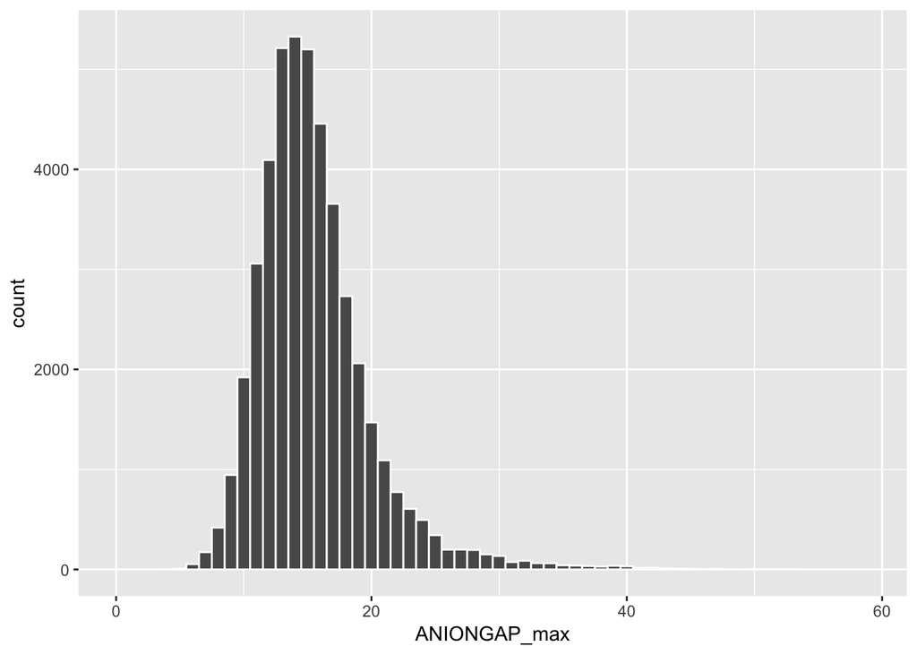

```r
hds %>% ggplot()+
  geom_histogram(aes(ANIONGAP_max), color="white", binwidth = 1)+
  scale_x_continuous(limits=c(0,59))
```

```r
# BICARBONATE_min: the MIN value in this is really low but possible. The max value is also possible. Keep as is.
#
# References:
# 1. Hiroyuki Arai et al. A Case of Poisoning by a Mixture of Methanol and Ethylene Glycol, The Tohoku Journal of Experimental Medicine, 1983, Volume 141, Issue 4, Pages 473-480, Released August 31, 2006,
# 2. Yessayan, L., Yee, J., Frinak, S., Kwon, D., & Szamosfalvi, B. (2015). Treatment of Severe Metabolic Alkalosis with Continuous Renal Replacement Therapy: Bicarbonate Kinetic Equations of Clinical Value. ASAIO journal, 61 4, e20-5.

summary(hds$BICARBONATE_min)
```

```
##    Min. 1st Qu.  Median    Mean 3rd Qu.    Max.
##     2.0    20.0    23.0    22.8    25.0    50.0
```

```r
# BICARBONATE_max:keep as is
#

summary(hds$BICARBONATE_max)
```

```
##    Min. 1st Qu.  Median    Mean 3rd Qu.    Max.
##    5.00   23.00   25.00   25.28   28.00   53.00
```

```r
# CREATININE_min: keep as is
#
# References (pediatric but still applies given the max):
# 1. Vimal Master Sankar Raj, Jessica Garcia, and Roberto Gordillo, “17-Year-Old Boy with Renal Failure and the Highest Reported Creatinine in Pediatric Literature,” Case Reports in Pediatrics, vol. 2015, Article ID 703960, 4 pages, 2015. https://doi.org/10.1155/2015/703960.

summary(hds$CREATININE_min)
```

```
##    Min. 1st Qu.  Median    Mean 3rd Qu.    Max.
##   0.100   0.700   0.900   1.234   1.300  28.000
```

```r
# CREATININE_max: keep as is
#
# Reference: same as before

summary(hds$CREATININE_max)
```

```
##    Min. 1st Qu.  Median    Mean 3rd Qu.    Max.
##   0.100   0.800   1.000   1.466   1.500  46.600
```

```r
# CHLORIDE_min: remove anything below 39, max is fine
#

summary(hds$CHLORIDE_min)
```

```
##    Min. 1st Qu.  Median    Mean 3rd Qu.    Max.
##     1.6    99.0   103.0   102.4   106.0   142.0
```

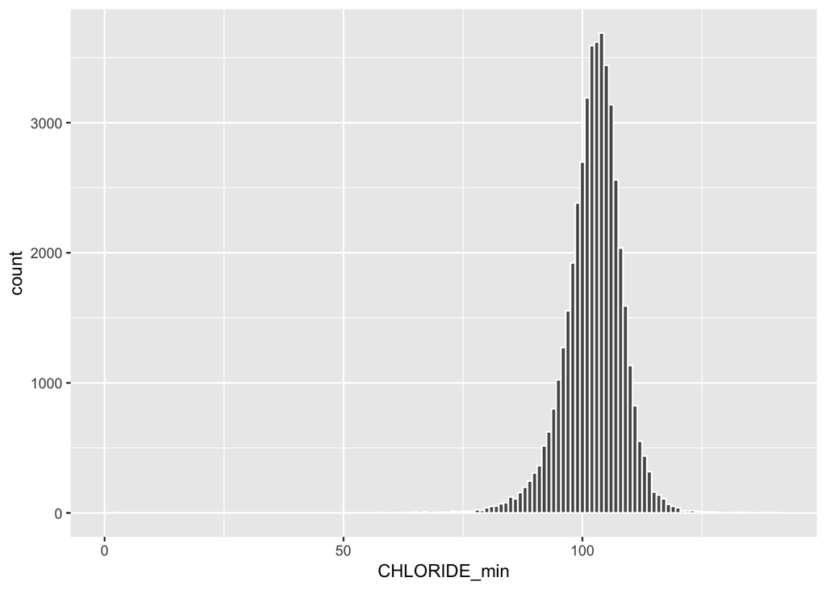

```r
hds %>% ggplot()+
  geom_histogram(aes(CHLORIDE_min), color="white", binwidth = 1)+
  scale_x_continuous(limits=c(0,142))
```

```r
hds %>% select(CHLORIDE_min) %>%
  filter(CHLORIDE_min <=75) %>%
  count(CHLORIDE_min)
```

```
## # A tibble: 22 x 2
##    CHLORIDE_min     n
##           <dbl> <int>
##  1          1.6     1
##  2          1.7     1
##  3          3.4     1
##  4         17       1
##  5         39       1
##  6         56       1
##  7         58       2
##  8         61       3
##  9         62       2
## 10         63       1
## # ... with 12 more rows
```

```r
# CHLORIDE_max: keep as is
#
# Reference:
# 1. Graber ML, Quigg RJ, Stempsey WE, Weis S. Spurious hyperchloremia and decreased anion gap in hyperlipidemia. Ann Intern Med. 1983 May;98(5 Pt 1):607-9.

summary(hds$CHLORIDE_max)
```

```
##    Min. 1st Qu.  Median    Mean 3rd Qu.    Max.
##    67.0   103.0   107.0   106.7   110.0   198.0
```

```r
# GLUCOSE_min: Remove anything below 20- the person is probably brain dead at that stage, Max reported is fine.
#
# References:
# 1. Cryer PE. Hypoglycemia, functional brain failure, and brain death. J Clin Invest. 2007;117(4):868-70.
# 2. Honda, Yasuyuki et al. A case of successful treatment of a patient with hyperglycemia of 2700 mg/dL. The American Journal of Emergency Medicine , Volume 30 , Issue 1 , 254.e1 - 254.e2

summary(hds$GLUCOSE_min)
```

```
##    Min. 1st Qu.  Median    Mean 3rd Qu.    Max.
##    1.15   90.00  106.00  112.25  126.00  632.00
```

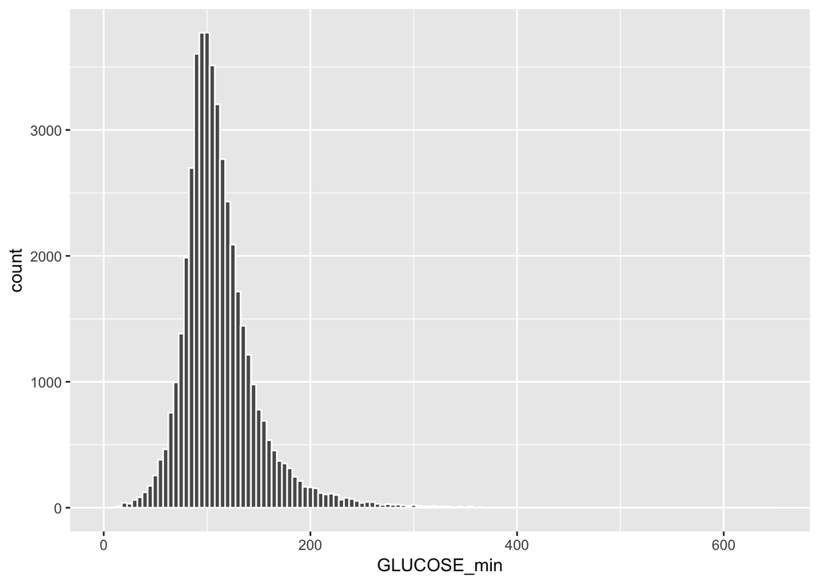

```r
hds %>% ggplot()+
  geom_histogram(aes(GLUCOSE_min), color="white", binwidth = 5)+
  scale_x_continuous(limits=c(0,651))
```

```r
hds %>% select(GLUCOSE_min) %>%
  filter(GLUCOSE_min <=70) %>%
  count(GLUCOSE_min)
```

```
## # A tibble: 63 x 2
##    GLUCOSE_min     n
##          <dbl> <int>
##  1        1.15     1
##  2        8        1
##  3        9        2
##  4       10        1
##  5       12        1
##  6       13        1
##  7       14        1
##  8       15        5
##  9       16        4
## 10       17        1
## # ... with 53 more rows
```

```r
# GLUCOSE_max: Keep as is
#

summary(hds$GLUCOSE_max)
```

```
##    Min. 1st Qu.  Median    Mean 3rd Qu.    Max.
##    26.0   123.0   154.0   177.2   197.0  2440.0
```

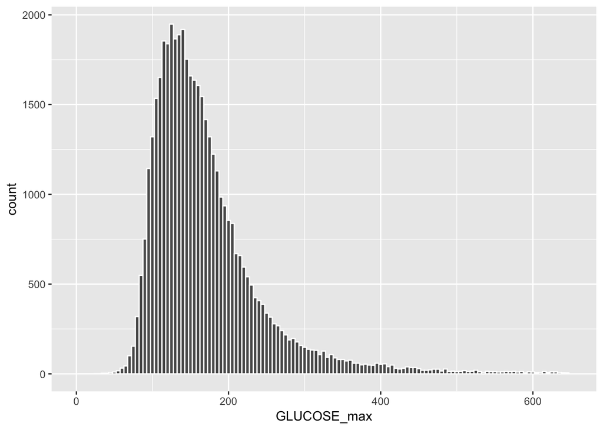

```r
hds %>% ggplot()+
  geom_histogram(aes(GLUCOSE_max), color="white", binwidth = 5)+
  scale_x_continuous(limits=c(0,651))
```

```r
hds %>% select(GLUCOSE_max) %>%
  filter(GLUCOSE_max >=198) %>%
  count(GLUCOSE_max)
```

```
## # A tibble: 718 x 2
##    GLUCOSE_max     n
##          <dbl> <int>
##  1         198   163
##  2         199   180
##  3         200   192
##  4         201   153
##  5         202   167
##  6         203   150
##  7         204   183
##  8         205   171
##  9         206   180
## 10         207   154
## # ... with 708 more rows
```

```r
# HEMATOCRIT_min: keep as is
#

# References:
# 1. M.K. Viele MD. R.B. Weiskopf.1.What canwelearn about the needfortransfusionfrompatientswho refuse blood? The experience with Jehovah’s Witnesses.May 1994 https://doi.org/10.1046/j.1537-2995.1994.34594249050.x

summary(hds$HEMATOCRIT_min)
```

```
##    Min. 1st Qu.  Median    Mean 3rd Qu.    Max.
##    4.00   25.50   29.60   29.89   34.10   66.20
```

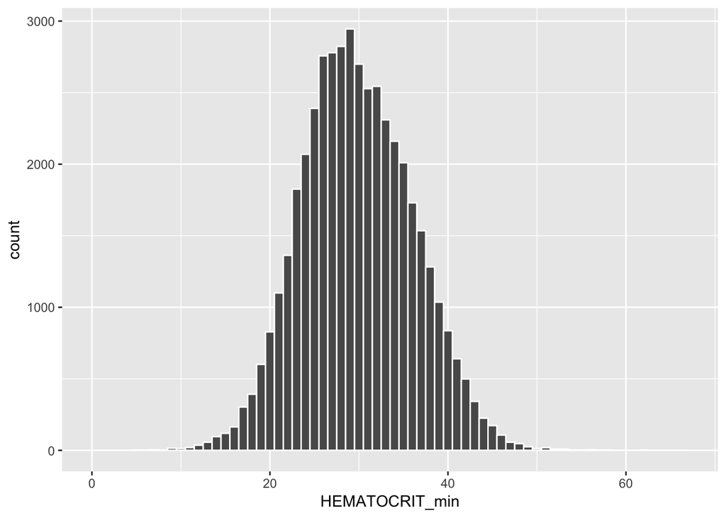

```r
hds %>% ggplot()+
  geom_histogram(aes(HEMATOCRIT_min), color="white", binwidth = 1)+
  scale_x_continuous(limits=c(0,67))
```

```r
hds %>% select(HEMATOCRIT_min) %>%
  filter(HEMATOCRIT_min <=25.5) %>%
  count(HEMATOCRIT_min)
```

```
## # A tibble: 169 x 2
##    HEMATOCRIT_min     n
##             <dbl> <int>
##  1            4       1
##  2            5       1
##  3            5.5     1
##  4            6.5     2
##  5            6.8     1
##  6            7       2
##  7            7.3     1
##  8            8       2
##  9            9       6
## 10            9.1     2
## # ... with 159 more rows
```

```r
# HEMATOCRIT_max: keep as is
#

summary(hds$HEMATOCRIT_max)
```

```
##    Min. 1st Qu.  Median    Mean 3rd Qu.    Max.
##   11.00   31.30   35.10   35.54   39.40   71.70
```

```r
hds %>% select(HEMATOCRIT_max) %>%
  filter(HEMATOCRIT_max >=39.40) %>%
  count(HEMATOCRIT_max)
```

```
## # A tibble: 194 x 2
##    HEMATOCRIT_max     n
##             <dbl> <int>
##  1           39.4   164
##  2           39.5   128
##  3           39.6   146
##  4           39.7   152
##  5           39.8   171
##  6           39.9   152
##  7           40     798
##  8           40.1   150
##  9           40.2   155
## 10           40.3   147
## # ... with 184 more rows
```

```r
# Hemoglobin: these should match the values of hematocrite/3 so keep both as is
#

summary(hds$HEMOGLOBIN_min)
```

```
##    Min. 1st Qu.  Median    Mean 3rd Qu.    Max.
##    1.20    8.60   10.00   10.15   11.60   20.30
```

```r
summary(hds$HEMOGLOBIN_max)
```

```
##    Min. 1st Qu.  Median    Mean 3rd Qu.    Max.
##    3.50   10.40   11.80   11.87   13.30   22.10
```

```r
# PLATELET_min: keep as is (Just in case that these values are value*10^3, eg. 100X10^3)
#
# Reference:
# 1. Anthony M. H. HoJoseph C. H. WooJohn G. KeltonLawrence Chiu. Spurious hyperkalaemia associated with severe thrombocytosis and leukocytosis.Can J Anaesth (1991) 38: 613. https://doi.org/10.1007/BF03008197
# 2. https://www.researchgate.net/post/what_is_the_minimum_platelet_count_ever_reported_in_a_patient_not_having_bleeding_complications

summary(hds$PLATELET_min)
```

```
##    Min. 1st Qu.  Median    Mean 3rd Qu.    Max.
##     5.0   136.0   193.0   209.3   260.0  1629.0
```

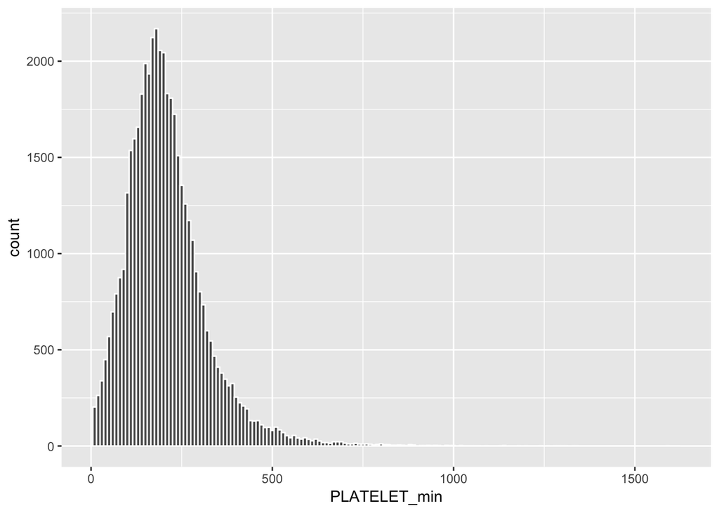

```r
hds %>% ggplot()+
  geom_histogram(aes(PLATELET_min), color="white", binwidth = 10)+
  scale_x_continuous(limits=c(0,1629))
```

```r
hds %>% select(PLATELET_min) %>%
  filter(PLATELET_min <=136) %>%
  count(PLATELET_min)
```

```
## # A tibble: 133 x 2
##    PLATELET_min     n
##           <dbl> <int>
##  1          5      21
##  2          5.5     1
##  3          6      13
##  4          7      16
##  5          8      15
##  6          9      14
##  7         10      23
##  8         11      22
##  9         12      20
## 10         13      23
## # ... with 123 more rows
```

```r
# PLATELET_min: keep as is they are high but it seems plausible
#
summary(hds$PLATELET_max)
```

```
##    Min. 1st Qu.  Median    Mean 3rd Qu.    Max.
##     6.0   170.0   229.0   249.8   303.0  2292.0
```

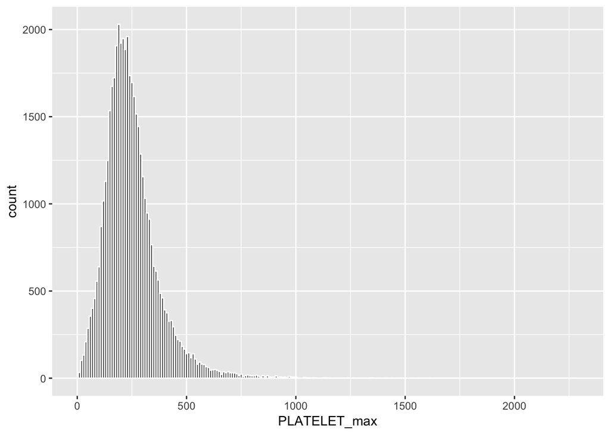

```r
hds %>% ggplot()+
  geom_histogram(aes(PLATELET_max), color="white", binwidth = 10)+
  scale_x_continuous(limits=c(0,2292))
```

```r
hds %>% select(PLATELET_max) %>%
  filter(PLATELET_max >=303) %>%
  count(PLATELET_max)
```

```
## # A tibble: 638 x 2
##    PLATELET_max     n
##           <dbl> <int>
##  1          303   122
##  2          304   106
##  3          305   123
##  4          306    94
##  5          307   105
##  6          308   109
##  7          309   106
##  8          310   114
##  9          311   109
## 10          312   105
## # ... with 628 more rows
```

```r
# POTASSIUM_MIN: Keep as is, or we can cut at 0.9 mmol/L (wouldnt make a difference).
#
# References:
# 1. ten Bos L, Veenstra T, Westerhof B et al. A case of extreme hypokalemia. Netherlands J of Medicine 2016; 74: 406-409
# 2. Tran H. Extreme hyperkalemia. South Med J 2005; 98: 729-32

summary(hds$POTASSIUM_min)
```

```
##    Min. 1st Qu.  Median    Mean 3rd Qu.    Max.
##    0.60    3.40    3.70    3.77    4.10    8.10
```

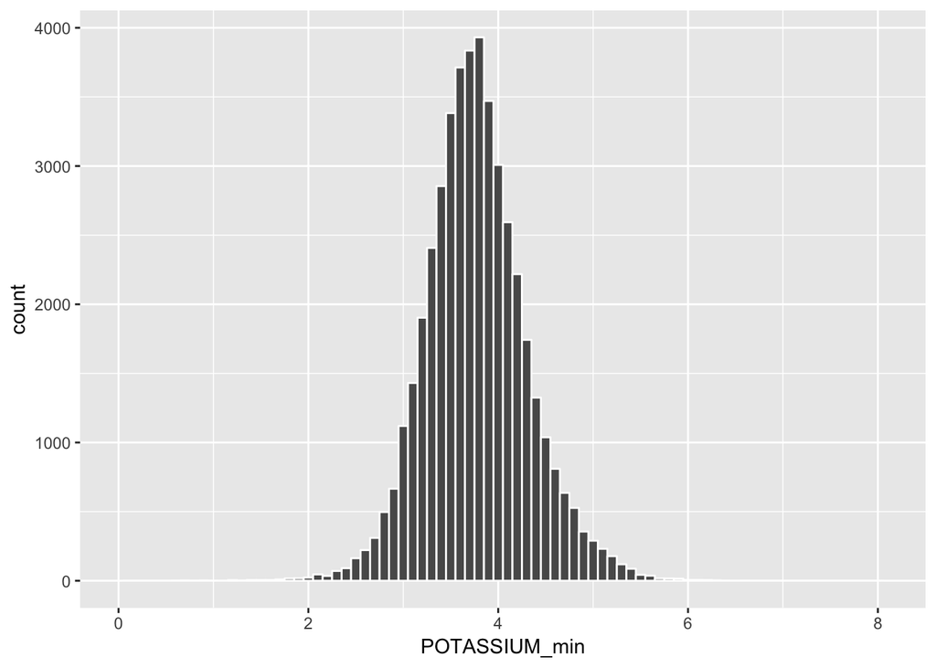

```r
hds %>% ggplot()+
  geom_histogram(aes(POTASSIUM_min), color="white", binwidth = 0.1)+
  scale_x_continuous(limits=c(0,8.1))
```

```r
hds %>% select(POTASSIUM_min) %>%
  filter(POTASSIUM_min <=3.4) %>%
  count(POTASSIUM_min)
```

```
## # A tibble: 28 x 2
##    POTASSIUM_min     n
##            <dbl> <int>
##  1           0.6     1
##  2           0.7     2
##  3           0.8     1
##  4           0.9     2
##  5           1       1
##  6           1.2     4
##  7           1.3     2
##  8           1.4     5
##  9           1.5     5
## 10           1.6     5
## # ... with 18 more rows
```

```r
# POTASSIUM_MAX: This is important. Cut out anything above 13.80. Min value is fine.
#
# References:
# Same as above

summary(hds$POTASSIUM_max)
```

```
##    Min. 1st Qu.  Median    Mean 3rd Qu.    Max.
##   2.300   4.000   4.400   4.649   5.000  27.500
```

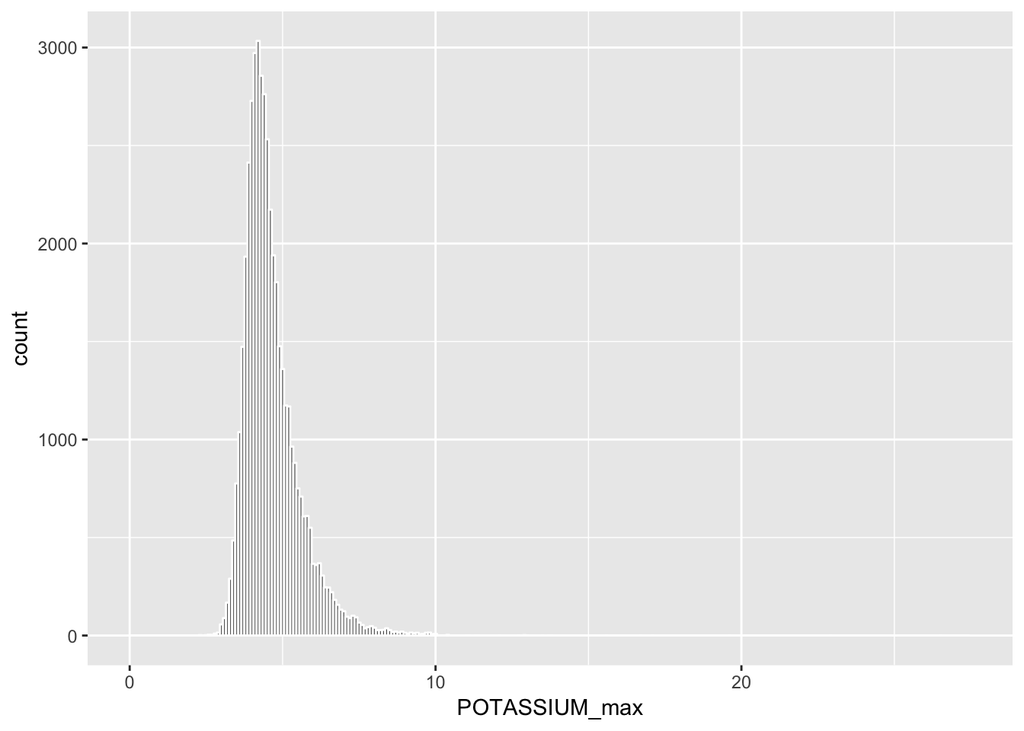

```r
hds %>% ggplot()+
  geom_histogram(aes(POTASSIUM_max), color="white", binwidth = 0.1)+
  scale_x_continuous(limits=c(0,27.5))
```

```r
hds %>% select(POTASSIUM_max) %>%
  filter(POTASSIUM_max >=5) %>%
  count(POTASSIUM_max)
```

```
## # A tibble: 75 x 2
##    POTASSIUM_max     n
##            <dbl> <int>
##  1          5     1360
##  2          5.1   1174
##  3          5.2   1169
##  4          5.3    964
##  5          5.4    881
##  6          5.5    750
##  7          5.52     1
##  8          5.6    709
##  9          5.7    608
## 10          5.8    610
## # ... with 65 more rows
```

```r
# SODIUM_MIN: A) cut below 99 or B) cut below 74.  Max here is fine
#
# Reference:
# Gupta E, Kunjal R, Cury J. Severe hyponatremia due to valproic acid toxicity. J Clinical Medicine Research 2015; 7: 717-19

summary(hds$SODIUM_min)
```

```
##    Min. 1st Qu.  Median    Mean 3rd Qu.    Max.
##    1.21  134.00  137.00  136.61  139.00  178.00
```

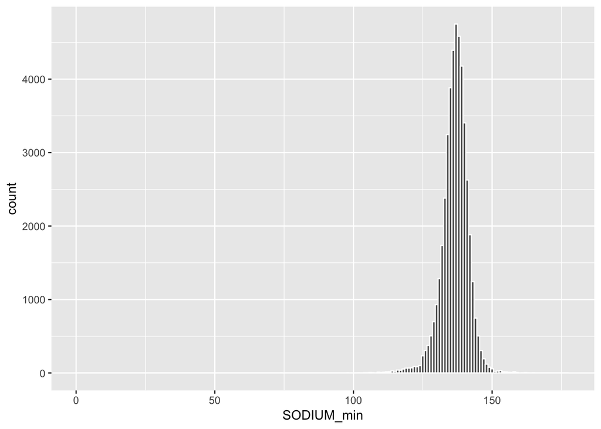

```r
hds %>% ggplot()+
  geom_histogram(aes(SODIUM_min), color="white", binwidth = 1)+
  scale_x_continuous(limits=c(0,178))
```

```r
hds %>% select(SODIUM_min) %>%
  filter(SODIUM_min <=134) %>%
  count(SODIUM_min)
```

```
## # A tibble: 44 x 2
##    SODIUM_min     n
##         <dbl> <int>
##  1       1.21     1
##  2       3.8      1
##  3      13        1
##  4      74        2
##  5      82        1
##  6      86        1
##  7      95        1
##  8      96        1
##  9      97        1
## 10      98        2
## # ... with 34 more rows
```

```r
# SODIUM_MAXl Keep as is
#

summary(hds$SODIUM_max)
```

```
##    Min. 1st Qu.  Median    Mean 3rd Qu.    Max.
##   108.0   138.0   140.0   140.1   142.0   182.0
```

```r
# BUN_min: Keep as is. It's incredibly high (higher than highest reported in literature) but it's possible
#
# Reference:
# 1. 17-Year-Old Boy with Renal Failure and the Highest Reported Creatinine in Pediatric Literature

summary(hds$BUN_min)
```

```
##    Min. 1st Qu.  Median    Mean 3rd Qu.    Max.
##    1.00   12.00   17.00   23.67   28.00  254.00
```

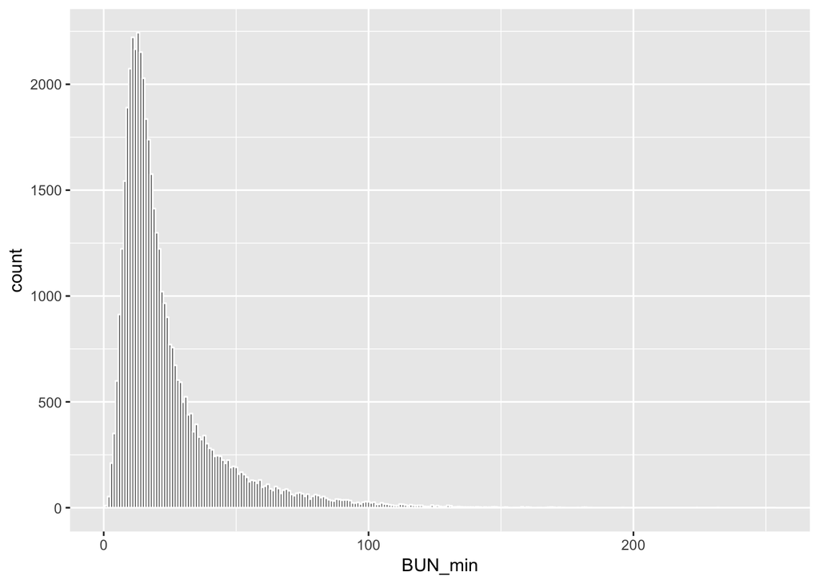

```r
hds %>% ggplot()+
  geom_histogram(aes(BUN_min), color="white", binwidth = 1)+
  scale_x_continuous(limits=c(0,254))
```